# 1. Generalization

## 1.1 Best Pre-forming Model

This was the model that was recorded during the process of Grid Search, the best preforming model uses the optimizer Adamax and has a learning rate of 0.01 which had a recorded accuracy of 78% which was 2% higher then using the optimizer Adam.

### 1.1.1 Import the Required Libraries

```python
import tensorflow as tf
import numpy as np
import matplotlib
import matplotlib.pyplot as plt
from tensorflow.keras.models import Sequential
from tensorflow.keras.layers import Dense, Dropout, Activation, Flatten, Conv2D, MaxPooling2D, AveragePooling2D, GaussianNoise
from tensorflow.python.keras.optimizers import Adamax
import pickle

%matplotlib inline
```

### 1.1.2 Load in the Data

```python
X = pickle.load(open("X.pickle","rb"))
y = pickle.load(open("y.pickle","rb"))
```

### 1.1.3 Set the Random Seed

```python
np.random.seed(1)
```

### 1.1.4 Normalize the Data

```python
X = X/255.0
```

### 1.1.5 Create the Model

```python
model = Sequential()

model.add(Conv2D(16, (3,3), dilation_rate=2, strides=1, kernel_initializer='normal', input_shape = X.shape[1:]))
model.add(Activation("relu"))
model.add(MaxPooling2D(pool_size=(2,2), padding="same"))

model.add(Conv2D(32, (3,3), dilation_rate=2, strides=1, kernel_initializer='normal'))
model.add(Activation("relu"))
model.add(MaxPooling2D(pool_size=(2,2), padding="same"))

model.add(Conv2D(64, (3,3), dilation_rate=2, strides=1, kernel_initializer='normal'))
model.add(Activation("relu"))
model.add(MaxPooling2D(pool_size=(2,2), padding="same"))

model.add(Conv2D(128, (3,3), dilation_rate=2, strides=1, kernel_initializer='normal'))
model.add(Activation("relu"))
model.add(MaxPooling2D(pool_size=(2,2), padding="same"))

model.add(Flatten())
model.add(Dense(32, kernel_initializer='normal'))
model.add(Activation("relu"))

model.add(Dense(32, kernel_initializer='normal'))
model.add(Activation("relu"))

model.add(Dense(32, kernel_initializer='normal'))
model.add(Activation("relu"))

model.add(Dense(1))
model.add(Activation("sigmoid"))

optimizer = Adamax(lr=0.01)

model.compile(loss="binary_crossentropy",
             optimizer=optimizer,
             metrics=['accuracy'])
```

### 1.1.6 Fit the Model

```python
genral = model.fit(X, y, batch_size=64, epochs=50, validation_split=0.33)
```

```
Train on 334 samples, validate on 166 samples
```

### 1.1.7 Visualise the Models Performance

The model is still overfitting, this is proven as the validation accuracy increases so does its loss. The models training accuracy also caps at 100%.

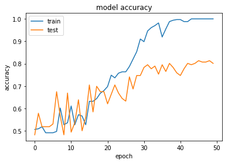

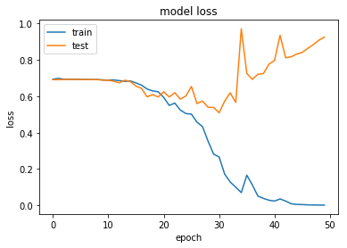

```python
plt.plot(genral.history['acc'])
plt.plot(genral.history['val_acc'])
plt.title('model accuracy')
plt.ylabel('accuracy')
plt.xlabel('epoch')
plt.legend(['train', 'test'], loc='upper left')
plt.show()

plt.plot(genral.history['loss'])
plt.plot(genral.history['val_loss'])
plt.title('model loss')
plt.ylabel('loss')
plt.xlabel('epoch')
plt.legend(['train', 'test'], loc='upper left')
plt.show()
```

### 1.1.8 Summarise the Model

```python
model.summary()
```

```
_________________________________________________________________
Layer (type)                 Output Shape              Param #
=================================================================
conv2d (Conv2D)              (None, 60, 60, 16)        160
_________________________________________________________________
activation (Activation)      (None, 60, 60, 16)        0
_________________________________________________________________
max_pooling2d (MaxPooling2D) (None, 30, 30, 16)        0
_________________________________________________________________
conv2d_1 (Conv2D)            (None, 26, 26, 32)        4640
_________________________________________________________________
activation_1 (Activation)    (None, 26, 26, 32)        0
_________________________________________________________________
max_pooling2d_1 (MaxPooling2 (None, 13, 13, 32)        0
_________________________________________________________________
conv2d_2 (Conv2D)            (None, 9, 9, 64)          18496
_________________________________________________________________
activation_2 (Activation)    (None, 9, 9, 64)          0
_________________________________________________________________
max_pooling2d_2 (MaxPooling2 (None, 5, 5, 64)          0
_________________________________________________________________
conv2d_3 (Conv2D)            (None, 1, 1, 128)         73856
_________________________________________________________________
activation_3 (Activation)    (None, 1, 1, 128)         0
_________________________________________________________________
max_pooling2d_3 (MaxPooling2 (None, 1, 1, 128)         0
_________________________________________________________________
flatten (Flatten)            (None, 128)               0
_________________________________________________________________
dense (Dense)                (None, 32)                4128
_________________________________________________________________
activation_4 (Activation)    (None, 32)                0
_________________________________________________________________
dense_1 (Dense)              (None, 32)                1056
_________________________________________________________________
activation_5 (Activation)    (None, 32)                0
_________________________________________________________________
dense_2 (Dense)              (None, 32)                1056
_________________________________________________________________
activation_6 (Activation)    (None, 32)                0
_________________________________________________________________
dense_3 (Dense)              (None, 1)                 33
_________________________________________________________________
activation_7 (Activation)    (None, 1)                 0
=================================================================
Total params: 103,425
Trainable params: 103,425
Non-trainable params: 0
_________________________________________________________________
```

## 1.2 Dropout

### 1.2.1 Convolutional Layers

#### 1.2.1.1 Create the Model

```python
model = Sequential()

model.add(Conv2D(16, (3,3), dilation_rate=2, strides=1, kernel_initializer='normal', input_shape = X.shape[1:]))
model.add(Activation("relu"))
model.add(MaxPooling2D(pool_size=(2,2), padding="same"))
model.add(Dropout(0.1))

model.add(Conv2D(32, (3,3), dilation_rate=2, strides=1, kernel_initializer='normal'))
model.add(Activation("relu"))
model.add(MaxPooling2D(pool_size=(2,2), padding="same"))
model.add(Dropout(0.1))

model.add(Conv2D(64, (3,3), dilation_rate=2, strides=1, kernel_initializer='normal'))
model.add(Activation("relu"))
model.add(MaxPooling2D(pool_size=(2,2), padding="same"))
model.add(Dropout(0.1))

model.add(Conv2D(128, (3,3), dilation_rate=2, strides=1, kernel_initializer='normal'))
model.add(Activation("relu"))
model.add(MaxPooling2D(pool_size=(2,2), padding="same"))
model.add(Dropout(0.1))

model.add(Flatten())
model.add(Dense(32, kernel_initializer='normal'))
model.add(Activation("relu"))

model.add(Dense(32, kernel_initializer='normal'))
model.add(Activation("relu"))

model.add(Dense(32, kernel_initializer='normal'))
model.add(Activation("relu"))

model.add(Dense(1))
model.add(Activation("sigmoid"))

optimizer = Adamax(lr=0.01)

model.compile(loss="binary_crossentropy",
             optimizer=optimizer,
             metrics=['accuracy'])
```

#### 1.2.1.2 Fit the Model

```python
dropout_01 = model.fit(X, y, batch_size=64, epochs=50, validation_split=0.33)
```

```
Train on 334 samples, validate on 166 samples
```

#### 1.2.1.3 Visualise the Results

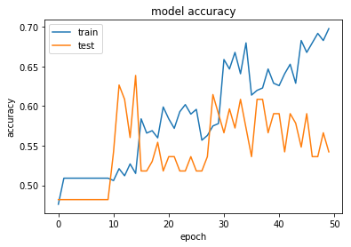

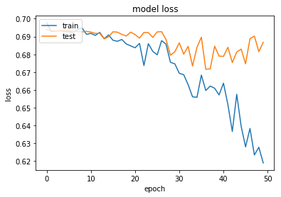

```python
plt.plot(dropout_06.history['acc'])
plt.plot(dropout_06.history['val_acc'])
plt.title('model accuracy')
plt.ylabel('accuracy')
plt.xlabel('epoch')
plt.legend(['train', 'test'], loc='upper left')
plt.show()

plt.plot(dropout_06.history['loss'])
plt.plot(dropout_06.history['val_loss'])
plt.title('model loss')
plt.ylabel('loss')
plt.xlabel('epoch')
plt.legend(['train', 'test'], loc='upper left')
plt.show()
```

#### 1.2.1.4 Sub-plot of Results - Loss

The model no longer converges and the results belwo indicate that the best results recorded were using a dropout value of both 0.2 and 0.3.

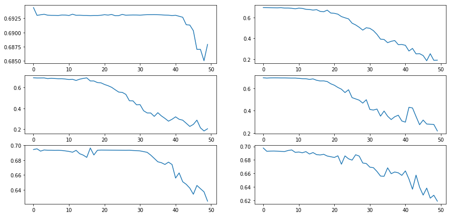

```python
fig = plt.figure(figsize=(15,15))

plt.subplot(6, 2, 1)
plt.plot(dropout_01.history['loss'])

plt.subplot(6, 2, 2)
plt.plot(dropout_02.history['loss'])

plt.subplot(6, 2, 3)
plt.plot(dropout_03.history['loss'])

plt.subplot(6, 2, 4)
plt.plot(dropout_04.history['loss'])

plt.subplot(6, 2, 5)
plt.plot(dropout_05.history['loss'])

plt.subplot(6, 2, 6)
plt.plot(dropout_06.history['loss'])
```

#### 1.2.1.5 Plot the Results - Accuracy

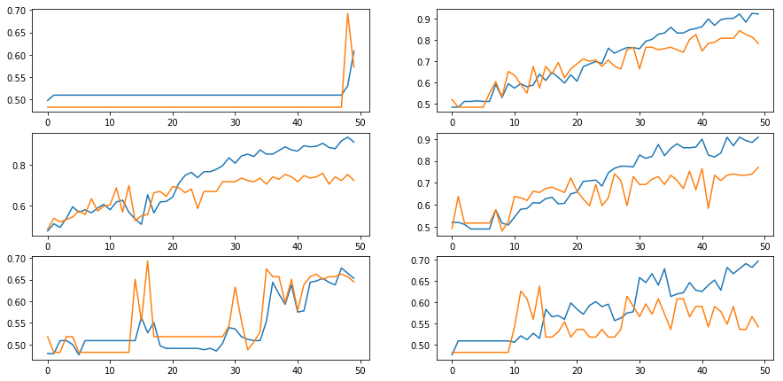

```python
fig = plt.figure(figsize=(15,15))

plt.subplot(6, 2, 1)
plt.plot(dropout_01.history['acc'])
plt.plot(dropout_01.history['val_acc'])

plt.subplot(6, 2, 2)
plt.plot(dropout_02.history['acc'])
plt.plot(dropout_02.history['val_acc'])

plt.subplot(6, 2, 3)
plt.plot(dropout_03.history['acc'])
plt.plot(dropout_03.history['val_acc'])

plt.subplot(6, 2, 4)
plt.plot(dropout_04.history['acc'])
plt.plot(dropout_04.history['val_acc'])

plt.subplot(6, 2, 5)
plt.plot(dropout_05.history['acc'])
plt.plot(dropout_05.history['val_acc'])

plt.subplot(6, 2, 6)
plt.plot(dropout_06.history['acc'])
plt.plot(dropout_06.history['val_acc'])
```

### 1.2.2 Dense Layers

#### 1.2.2.1 Create the Model

```python
model = Sequential()

model.add(Conv2D(16, (3,3), dilation_rate=2, strides=1, kernel_initializer='normal', input_shape = X.shape[1:]))
model.add(Activation("relu"))
model.add(MaxPooling2D(pool_size=(2,2), padding="same"))

model.add(Conv2D(32, (3,3), dilation_rate=2, strides=1, kernel_initializer='normal'))
model.add(Activation("relu"))
model.add(MaxPooling2D(pool_size=(2,2), padding="same"))

model.add(Conv2D(64, (3,3), dilation_rate=2, strides=1, kernel_initializer='normal'))
model.add(Activation("relu"))
model.add(MaxPooling2D(pool_size=(2,2), padding="same"))

model.add(Conv2D(128, (3,3), dilation_rate=2, strides=1, kernel_initializer='normal'))
model.add(Activation("relu"))
model.add(MaxPooling2D(pool_size=(2,2), padding="same"))

model.add(Flatten())
model.add(Dense(32, kernel_initializer='normal'))
model.add(Activation("relu"))
model.add(Dropout(0.5))

model.add(Dense(32, kernel_initializer='normal'))
model.add(Activation("relu"))
model.add(Dropout(0.5))

model.add(Dense(32, kernel_initializer='normal'))
model.add(Activation("relu"))
model.add(Dropout(0.5))

model.add(Dense(1))
model.add(Activation("sigmoid"))

optimizer = Adamax(lr=0.01)

model.compile(loss="binary_crossentropy",
             optimizer=optimizer,
             metrics=['accuracy'])
```

#### 1.2.2.2 Fit the Model

```python
dense_05 = model.fit(X, y, batch_size=64, epochs=50, validation_split=0.33)
```

```
Train on 334 samples, validate on 166 samples
```

#### 1.2.2.3 Visualise the Results

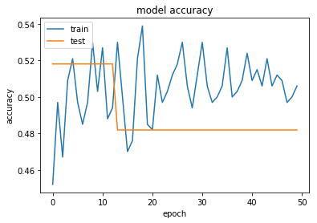

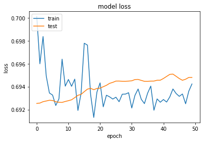

```python
plt.plot(dense_09.history['acc'])
plt.plot(dense_09.history['val_acc'])
plt.title('model accuracy')
plt.ylabel('accuracy')
plt.xlabel('epoch')
plt.legend(['train', 'test'], loc='upper left')
plt.show()

plt.plot(dense_09.history['loss'])
plt.plot(dense_09.history['val_loss'])
plt.title('model loss')
plt.ylabel('loss')
plt.xlabel('epoch')
plt.legend(['train', 'test'], loc='upper left')
plt.show()
```

#### 1.2.2.4 Sub-plot the Results - Loss

Just like results recorded on the Convolutional Layers the models loss does not converge after 50 epochs, this epoch range is quite small for the data-range however I stuck with this as Grid Search indicated that 50 epochs produeced the best preforming mode. Here the best results were recorded using values of 0.1, 0.2, 0.3 and 0.4.

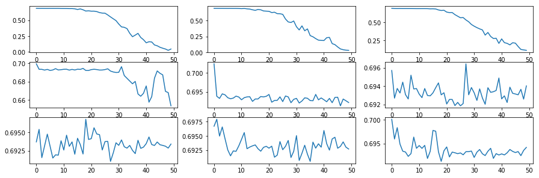

```python
fig = plt.figure(figsize=(15,15))

plt.subplot(9, 3, 1)
plt.plot(dense_01.history['loss'])

plt.subplot(9, 3, 2)
plt.plot(dense_02.history['loss'])

plt.subplot(9, 3, 3)
plt.plot(dense_03.history['loss'])

plt.subplot(9, 3, 4)
plt.plot(dense_04.history['loss'])

plt.subplot(9, 3, 5)
plt.plot(dense_05.history['loss'])

plt.subplot(9, 3, 6)
plt.plot(dense_06.history['loss'])

plt.subplot(9, 3, 7)
plt.plot(dense_07.history['loss'])

plt.subplot(9, 3, 8)
plt.plot(dense_08.history['loss'])

plt.subplot(9, 3, 9)
plt.plot(dense_09.history['loss'])
```

#### 1.2.2.5 Sub-plot the Results - Accuracy

The best recorded results here are in the range of 0.1-0.4. These 4 values will be extracted and further experiments will be undertaken using these values.

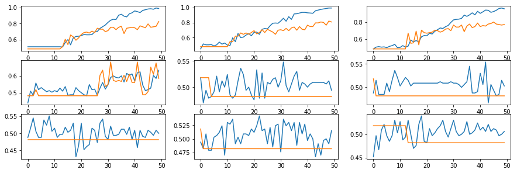

```python
fig = plt.figure(figsize=(15,15))

plt.subplot(9, 3, 1)
plt.plot(dense_01.history['acc'])
plt.plot(dense_01.history['val_acc'])

plt.subplot(9, 3, 2)
plt.plot(dense_02.history['acc'])
plt.plot(dense_02.history['val_acc'])

plt.subplot(9, 3, 3)
plt.plot(dense_03.history['acc'])
plt.plot(dense_03.history['val_acc'])

plt.subplot(9, 3, 4)
plt.plot(dense_04.history['acc'])
plt.plot(dense_04.history['val_acc'])

plt.subplot(9, 3, 5)
plt.plot(dense_05.history['acc'])
plt.plot(dense_05.history['val_acc'])

plt.subplot(9, 3, 6)
plt.plot(dense_06.history['acc'])
plt.plot(dense_06.history['val_acc'])

plt.subplot(9, 3, 7)
plt.plot(dense_07.history['acc'])
plt.plot(dense_07.history['val_acc'])

plt.subplot(9, 3, 8)
plt.plot(dense_08.history['acc'])
plt.plot(dense_08.history['val_acc'])

plt.subplot(9, 3, 9)
plt.plot(dense_09.history['acc'])
plt.plot(dense_09.history['val_acc'])
```

### 1.2.3 Both Convolutional & Dense Layers

#### 1.2.3.1 Create the Model

```python
model = Sequential()

model.add(Conv2D(16, (3,3), dilation_rate=2, strides=1, kernel_initializer='normal', input_shape = X.shape[1:]))
model.add(Activation("relu"))
model.add(MaxPooling2D(pool_size=(2,2), padding="same"))
model.add(Dropout(0.4))

model.add(Conv2D(32, (3,3), dilation_rate=2, strides=1, kernel_initializer='normal'))
model.add(Activation("relu"))
model.add(MaxPooling2D(pool_size=(2,2), padding="same"))
model.add(Dropout(0.4))

model.add(Conv2D(64, (3,3), dilation_rate=2, strides=1, kernel_initializer='normal'))
model.add(Activation("relu"))
model.add(MaxPooling2D(pool_size=(2,2), padding="same"))
model.add(Dropout(0.4))

model.add(Conv2D(128, (3,3), dilation_rate=2, strides=1, kernel_initializer='normal'))
model.add(Activation("relu"))
model.add(MaxPooling2D(pool_size=(2,2), padding="same"))
model.add(Dropout(0.4))

model.add(Flatten())
model.add(Dense(32, kernel_initializer='normal'))
model.add(Activation("relu"))
model.add(Dropout(0.4))

model.add(Dense(32, kernel_initializer='normal'))
model.add(Activation("relu"))
model.add(Dropout(0.4))

model.add(Dense(32, kernel_initializer='normal'))
model.add(Activation("relu"))
model.add(Dropout(0.4))

model.add(Dense(1))
model.add(Activation("sigmoid"))

optimizer = Adamax(lr=0.01)

model.compile(loss="binary_crossentropy",
             optimizer=optimizer,
             metrics=['accuracy'])
```

#### 1.2.3.2 Fit the Model

```python
both_04 = model.fit(X, y, batch_size=64, epochs=50, validation_split=0.33)
```

```
Train on 334 samples, validate on 166 samples
```

#### 1.2.3.3 Visualise the Models Performance

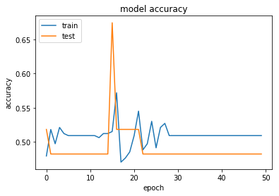

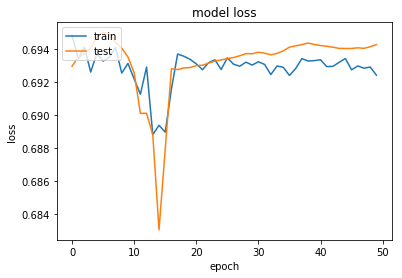

```python
plt.plot(both_03_04.history['acc'])
plt.plot(both_03_04.history['val_acc'])
plt.title('model accuracy')
plt.ylabel('accuracy')
plt.xlabel('epoch')
plt.legend(['train', 'test'], loc='upper left')
plt.show()

plt.plot(both_03_04.history['loss'])
plt.plot(both_03_04.history['val_loss'])
plt.title('model loss')
plt.ylabel('loss')
plt.xlabel('epoch')
plt.legend(['train', 'test'], loc='upper left')
plt.show()
```

#### 1.2.3.4 Sub-plot the Results - Loss

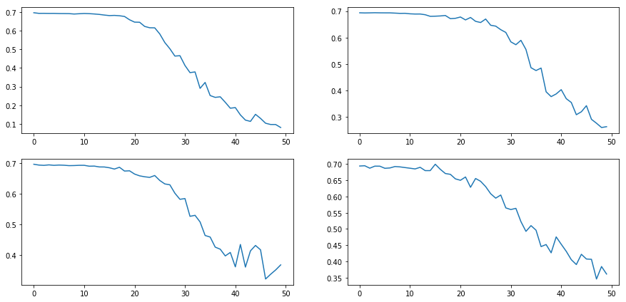

```python
fig = plt.figure(figsize=(15,15))

plt.subplot(4, 2, 1)
plt.plot(both_01.history['loss'])

plt.subplot(4, 2, 2)
plt.plot(both_02.history['loss'])

plt.subplot(4, 2, 3)
plt.plot(both_03.history['loss'])

plt.subplot(4, 2, 4)
plt.plot(both_04.history['loss'])
```

#### 1.2.3.5 Sub-plot the Results - Accuracy

Using a dropout value of 0.2 on both the Convolutional Layers and the Dense Layers seems to produce the best overall results thus far. However more tests will be conducted to discover if this statement is indeed true.

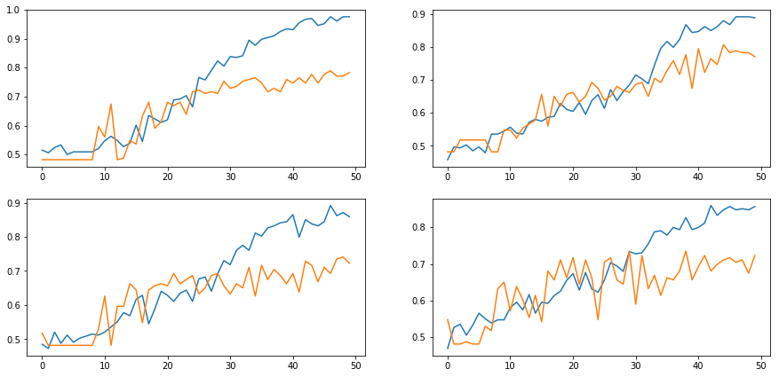

```python
fig = plt.figure(figsize=(15,15))

plt.subplot(4, 2, 1)
plt.plot(both_01.history['acc'])
plt.plot(both_01.history['val_acc'])

plt.subplot(4, 2, 2)
plt.plot(both_02.history['acc'])
plt.plot(both_02.history['val_acc'])

plt.subplot(4, 2, 3)
plt.plot(both_03.history['acc'])
plt.plot(both_03.history['val_acc'])

plt.subplot(4, 2, 4)
plt.plot(both_04.history['acc'])
plt.plot(both_04.history['val_acc'])
```

#### 1.2.3.6 Sub-plot the Results - Loss - Convolution 0.2

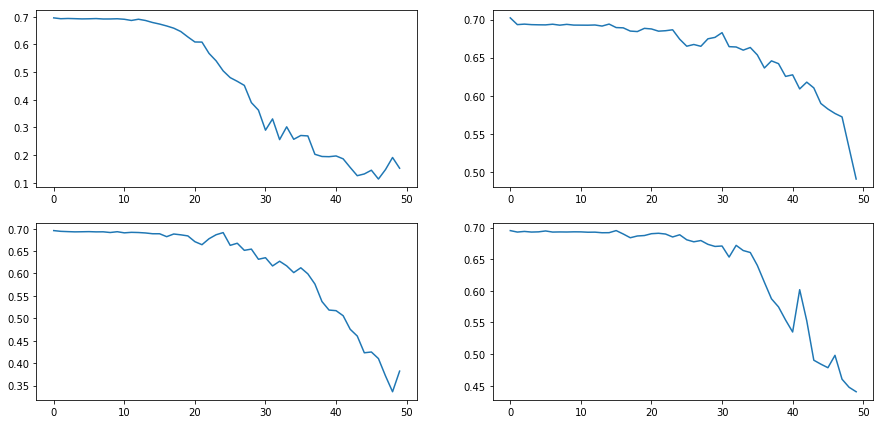

```python
fig = plt.figure(figsize=(15,15))

plt.subplot(4, 2, 1)
plt.plot(both_02_01.history['loss'])

plt.subplot(4, 2, 2)
plt.plot(both_02_02.history['loss'])

plt.subplot(4, 2, 3)
plt.plot(both_02_03.history['loss'])

plt.subplot(4, 2, 4)
plt.plot(both_02_04.history['loss'])
```

#### 1.2.3.5 Sub-plot the Results - Accuracy - Convolution 0.2

After a second run it is clear that only one value here stands out and this is using a dense layer value of 0.1 and a convolutional layer value of 0.2, although this result does not look very acccurate as the model seems to still overfit like it did before adding dropout.

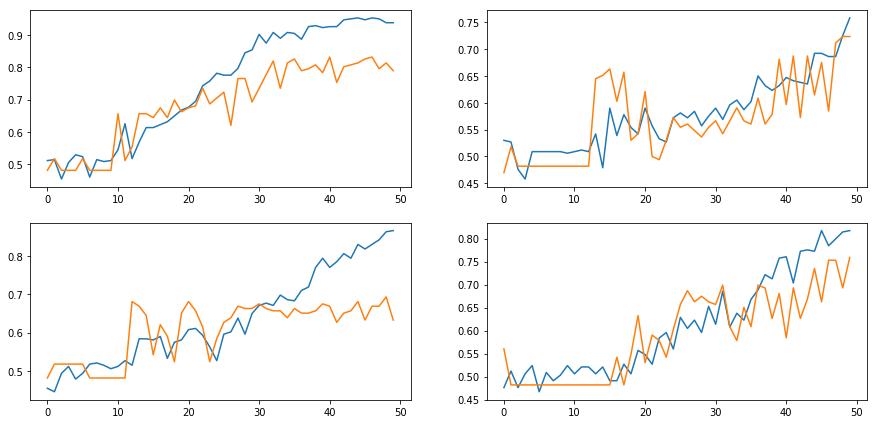

```python
fig = plt.figure(figsize=(15,15))

plt.subplot(4, 2, 1)
plt.plot(both_02_01.history['acc'])
plt.plot(both_02_01.history['val_acc'])

plt.subplot(4, 2, 2)
plt.plot(both_02_02.history['acc'])
plt.plot(both_02_02.history['val_acc'])

plt.subplot(4, 2, 3)
plt.plot(both_02_03.history['acc'])
plt.plot(both_02_03.history['val_acc'])

plt.subplot(4, 2, 4)
plt.plot(both_02_04.history['acc'])
plt.plot(both_02_04.history['val_acc'])
```

#### 1.2.3.6 Sub-plot the Results - Loss - Convolution 0.3

Using a value of 0.3 and 0.1 allows for the models loss to decrease, indicating that the model could converge with an increase in the models epoch range.

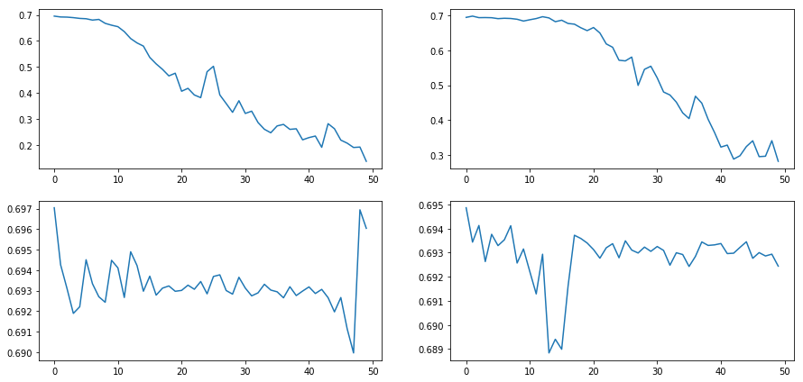

```python
fig = plt.figure(figsize=(15,15))

plt.subplot(4, 2, 1)
plt.plot(both_03_01.history['loss'])

plt.subplot(4, 2, 2)
plt.plot(both_03_02.history['loss'])

plt.subplot(4, 2, 3)
plt.plot(both_03_03.history['loss'])

plt.subplot(4, 2, 4)
plt.plot(both_03_04.history['loss'])
```

#### 1.2.3.7 Sub-plot the Results - Accuracy - Convolution 0.3

The chosen values for dropout are 0.3 convolutional layer and 0.1 on the dense layers. The diagrams below indicate that the first figure produces the best overall result in terms of accuracy and the models loss.

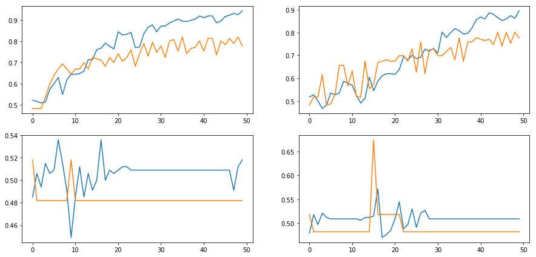

```python
fig = plt.figure(figsize=(15,15))

plt.subplot(4, 2, 1)
plt.plot(both_03_01.history['acc'])
plt.plot(both_03_01.history['val_acc'])

plt.subplot(4, 2, 2)
plt.plot(both_03_02.history['acc'])
plt.plot(both_03_02.history['val_acc'])

plt.subplot(4, 2, 3)
plt.plot(both_03_03.history['acc'])
plt.plot(both_03_03.history['val_acc'])

plt.subplot(4, 2, 4)
plt.plot(both_03_04.history['acc'])
plt.plot(both_03_04.history['val_acc'])
```

## 1.3 Bias

### 1.3.1 Convolutional Layer

#### 1.3.1.1 Create the Model

```python
model = Sequential()

model.add(Conv2D(16, (3,3), dilation_rate=2, strides=1, kernel_initializer='normal', use_bias=True, input_shape = X.shape[1:]))
model.add(Activation("relu"))
model.add(MaxPooling2D(pool_size=(2,2), padding="same"))
model.add(Dropout(0.3))

model.add(Conv2D(32, (3,3), dilation_rate=2, strides=1, kernel_initializer='normal', use_bias=True))
model.add(Activation("relu"))
model.add(MaxPooling2D(pool_size=(2,2), padding="same"))
model.add(Dropout(0.3))

model.add(Conv2D(64, (3,3), dilation_rate=2, strides=1, kernel_initializer='normal', use_bias=True))
model.add(Activation("relu"))
model.add(MaxPooling2D(pool_size=(2,2), padding="same"))
model.add(Dropout(0.3))

model.add(Conv2D(128, (3,3), dilation_rate=2, strides=1, kernel_initializer='normal', use_bias=True))
model.add(Activation("relu"))
model.add(MaxPooling2D(pool_size=(2,2), padding="same"))
model.add(Dropout(0.3))

model.add(Flatten())
model.add(Dense(32, kernel_initializer='normal'))
model.add(Activation("relu"))
model.add(Dropout(0.1))

model.add(Dense(32, kernel_initializer='normal'))
model.add(Activation("relu"))
model.add(Dropout(0.1))

model.add(Dense(32, kernel_initializer='normal'))
model.add(Activation("relu"))
model.add(Dropout(0.1))

model.add(Dense(1))
model.add(Activation("sigmoid"))

optimizer = Adamax(lr=0.01)

model.compile(loss="binary_crossentropy",
             optimizer=optimizer,
             metrics=['accuracy'])
```

#### 1.3.1.2 Fit the Model

```python
bias_conv = model.fit(X, y, batch_size=64, epochs=50, validation_split=0.33)
```

```
Train on 334 samples, validate on 166 samples
```

#### 1.3.1.3 Visualise the Results

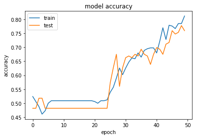

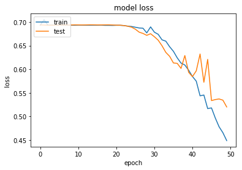

```python
plt.plot(bias_conv.history['acc'])
plt.plot(bias_conv.history['val_acc'])
plt.title('model accuracy')
plt.ylabel('accuracy')
plt.xlabel('epoch')
plt.legend(['train', 'test'], loc='upper left')
plt.show()

plt.plot(bias_conv.history['loss'])
plt.plot(bias_conv.history['val_loss'])
plt.title('model loss')
plt.ylabel('loss')
plt.xlabel('epoch')
plt.legend(['train', 'test'], loc='upper left')
plt.show()
```

### 1.3.2 Dense Layers

#### 1.3.2.1 Create the Model

```python
model = Sequential()

model.add(Conv2D(16, (3,3), dilation_rate=2, strides=1, kernel_initializer='normal', input_shape = X.shape[1:]))
model.add(Activation("relu"))
model.add(MaxPooling2D(pool_size=(2,2), padding="same"))
model.add(Dropout(0.3))

model.add(Conv2D(32, (3,3), dilation_rate=2, strides=1, kernel_initializer='normal'))
model.add(Activation("relu"))
model.add(MaxPooling2D(pool_size=(2,2), padding="same"))
model.add(Dropout(0.3))

model.add(Conv2D(64, (3,3), dilation_rate=2, strides=1, kernel_initializer='normal'))
model.add(Activation("relu"))
model.add(MaxPooling2D(pool_size=(2,2), padding="same"))
model.add(Dropout(0.3))

model.add(Conv2D(128, (3,3), dilation_rate=2, strides=1, kernel_initializer='normal'))
model.add(Activation("relu"))
model.add(MaxPooling2D(pool_size=(2,2), padding="same"))
model.add(Dropout(0.3))

model.add(Flatten())
model.add(Dense(32, kernel_initializer='normal', use_bias=True))
model.add(Activation("relu"))
model.add(Dropout(0.1))

model.add(Dense(32, kernel_initializer='normal', use_bias=True))
model.add(Activation("relu"))
model.add(Dropout(0.1))

model.add(Dense(32, kernel_initializer='normal', use_bias=True))
model.add(Activation("relu"))
model.add(Dropout(0.1))

model.add(Dense(1))
model.add(Activation("sigmoid"))

optimizer = Adamax(lr=0.01)

model.compile(loss="binary_crossentropy",
             optimizer=optimizer,
             metrics=['accuracy'])
```

#### 1.3.2.2 Fit the Model

```python
bias_dense = model.fit(X, y, batch_size=64, epochs=50, validation_split=0.33)
```

```
Train on 334 samples, validate on 166 samples
```

#### 1.3.2.3 Visualise the Results

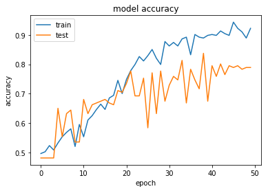

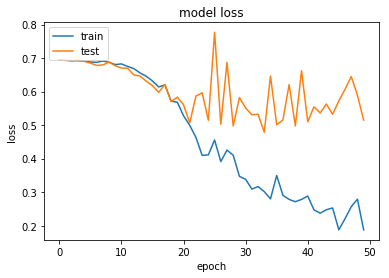

```python
plt.plot(bias_dense.history['acc'])
plt.plot(bias_dense.history['val_acc'])
plt.title('model accuracy')
plt.ylabel('accuracy')
plt.xlabel('epoch')
plt.legend(['train', 'test'], loc='upper left')
plt.show()

plt.plot(bias_dense.history['loss'])
plt.plot(bias_dense.history['val_loss'])
plt.title('model loss')
plt.ylabel('loss')
plt.xlabel('epoch')
plt.legend(['train', 'test'], loc='upper left')
plt.show()
```

### 1.3.3 Both Convolution & Dense Layers

#### 1.3.3.1 Create the Model

```python
model = Sequential()

model.add(Conv2D(16, (3,3), dilation_rate=2, strides=1, kernel_initializer='normal', use_bias=True, input_shape = X.shape[1:]))
model.add(Activation("relu"))
model.add(MaxPooling2D(pool_size=(2,2), padding="same"))
model.add(Dropout(0.3))

model.add(Conv2D(32, (3,3), dilation_rate=2, strides=1, kernel_initializer='normal', use_bias=True))
model.add(Activation("relu"))
model.add(MaxPooling2D(pool_size=(2,2), padding="same"))
model.add(Dropout(0.3))

model.add(Conv2D(64, (3,3), dilation_rate=2, strides=1, kernel_initializer='normal', use_bias=True))
model.add(Activation("relu"))
model.add(MaxPooling2D(pool_size=(2,2), padding="same"))
model.add(Dropout(0.3))

model.add(Conv2D(128, (3,3), dilation_rate=2, strides=1, kernel_initializer='normal', use_bias=True))
model.add(Activation("relu"))
model.add(MaxPooling2D(pool_size=(2,2), padding="same"))
model.add(Dropout(0.3))

model.add(Flatten())
model.add(Dense(32, kernel_initializer='normal', use_bias=True))
model.add(Activation("relu"))
model.add(Dropout(0.1))

model.add(Dense(32, kernel_initializer='normal', use_bias=True))
model.add(Activation("relu"))
model.add(Dropout(0.1))

model.add(Dense(32, kernel_initializer='normal', use_bias=True))
model.add(Activation("relu"))
model.add(Dropout(0.1))

model.add(Dense(1))
model.add(Activation("sigmoid"))

optimizer = Adamax(lr=0.01)

model.compile(loss="binary_crossentropy",
             optimizer=optimizer,
             metrics=['accuracy'])
```

#### 1.3.3.2 Fit the Model

```python
bias_both = model.fit(X, y, batch_size=64, epochs=50, validation_split=0.33)
```

```
Train on 334 samples, validate on 166 samples
```

#### 1.3.3.3 Visualise the Results

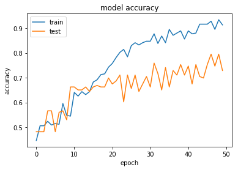

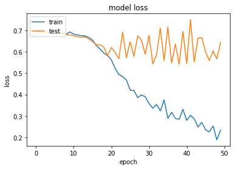

```python
plt.plot(bias_both.history['acc'])
plt.plot(bias_both.history['val_acc'])
plt.title('model accuracy')
plt.ylabel('accuracy')
plt.xlabel('epoch')
plt.legend(['train', 'test'], loc='upper left')
plt.show()

plt.plot(bias_both.history['loss'])
plt.plot(bias_both.history['val_loss'])
plt.title('model loss')
plt.ylabel('loss')
plt.xlabel('epoch')
plt.legend(['train', 'test'], loc='upper left')
plt.show()
```

## 1.4 Adding Noise

### 1.4.1 Convolutional Layers

#### 1.4.1.1 Create the Model

```python
model = Sequential()

model.add(Conv2D(16, (3,3), dilation_rate=2, strides=1, kernel_initializer='normal', use_bias=True, input_shape = X.shape[1:]))
model.add(GaussianNoise(0.1))
model.add(Activation("relu"))
model.add(MaxPooling2D(pool_size=(2,2), padding="same"))
model.add(Dropout(0.3))

model.add(Conv2D(32, (3,3), dilation_rate=2, strides=1, kernel_initializer='normal', use_bias=True))
model.add(Activation("relu"))
model.add(GaussianNoise(0.1))
model.add(MaxPooling2D(pool_size=(2,2), padding="same"))
model.add(Dropout(0.3))

model.add(Conv2D(64, (3,3), dilation_rate=2, strides=1, kernel_initializer='normal', use_bias=True))
model.add(Activation("relu"))
model.add(GaussianNoise(0.1))
model.add(MaxPooling2D(pool_size=(2,2), padding="same"))
model.add(Dropout(0.3))

model.add(Conv2D(128, (3,3), dilation_rate=2, strides=1, kernel_initializer='normal', use_bias=True))
model.add(Activation("relu"))
model.add(GaussianNoise(0.1))
model.add(MaxPooling2D(pool_size=(2,2), padding="same"))
model.add(Dropout(0.3))

model.add(Flatten())
model.add(Dense(32, kernel_initializer='normal', use_bias=True))
model.add(Activation("relu"))
model.add(Dropout(0.1))

model.add(Dense(32, kernel_initializer='normal', use_bias=True))
model.add(Activation("relu"))
model.add(Dropout(0.1))

model.add(Dense(32, kernel_initializer='normal', use_bias=True))
model.add(Activation("relu"))
model.add(Dropout(0.1))

model.add(Dense(1))
model.add(Activation("sigmoid"))

optimizer = Adamax(lr=0.01)

model.compile(loss="binary_crossentropy",
             optimizer=optimizer,
             metrics=['accuracy'])
```

#### 1.4.1.2 Fit the Model

```python
noise_conv = model.fit(X, y, batch_size=64, epochs=50, validation_split=0.33)
```

```
Train on 334 samples, validate on 166 samples
```

#### 1.4.1.3 Visualise the Results

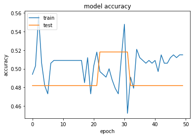

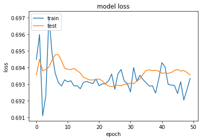

```python
plt.plot(noise_conv.history['acc'])
plt.plot(noise_conv.history['val_acc'])
plt.title('model accuracy')
plt.ylabel('accuracy')
plt.xlabel('epoch')
plt.legend(['train', 'test'], loc='upper left')
plt.show()

plt.plot(noise_conv.history['loss'])
plt.plot(noise_conv.history['val_loss'])
plt.title('model loss')
plt.ylabel('loss')
plt.xlabel('epoch')
plt.legend(['train', 'test'], loc='upper left')
plt.show()
```

### 1.4.2 Dense Layers

#### 1.4.2.1 Create the Model

```python
model = Sequential()

model.add(Conv2D(16, (3,3), dilation_rate=2, strides=1, kernel_initializer='normal', use_bias=True, input_shape = X.shape[1:]))
model.add(Activation("relu"))
model.add(MaxPooling2D(pool_size=(2,2), padding="same"))
model.add(Dropout(0.3))

model.add(Conv2D(32, (3,3), dilation_rate=2, strides=1, kernel_initializer='normal', use_bias=True))
model.add(Activation("relu"))
model.add(MaxPooling2D(pool_size=(2,2), padding="same"))
model.add(Dropout(0.3))

model.add(Conv2D(64, (3,3), dilation_rate=2, strides=1, kernel_initializer='normal', use_bias=True))
model.add(Activation("relu"))
model.add(MaxPooling2D(pool_size=(2,2), padding="same"))
model.add(Dropout(0.3))

model.add(Conv2D(128, (3,3), dilation_rate=2, strides=1, kernel_initializer='normal', use_bias=True))
model.add(Activation("relu"))
model.add(MaxPooling2D(pool_size=(2,2), padding="same"))
model.add(Dropout(0.3))

model.add(Flatten())
model.add(Dense(32, kernel_initializer='normal', use_bias=True))
model.add(GaussianNoise(0.4))
model.add(Activation("relu"))
model.add(Dropout(0.1))

model.add(Dense(32, kernel_initializer='normal', use_bias=True))
model.add(GaussianNoise(0.4))
model.add(Activation("relu"))
model.add(Dropout(0.1))

model.add(Dense(32, kernel_initializer='normal', use_bias=True))
model.add(Activation("relu"))
model.add(GaussianNoise(0.4))
model.add(Dropout(0.1))

model.add(Dense(1))
model.add(Activation("sigmoid"))

optimizer = Adamax(lr=0.01)

model.compile(loss="binary_crossentropy",
             optimizer=optimizer,
             metrics=['accuracy'])
```

#### 1.4.2.2 Fit the Model

```python
noise_dense_04 = model.fit(X, y, batch_size=64, epochs=50, validation_split=0.33)
```

```
Train on 334 samples, validate on 166 samples
```

#### 1.4.2.3 Visualise the Results

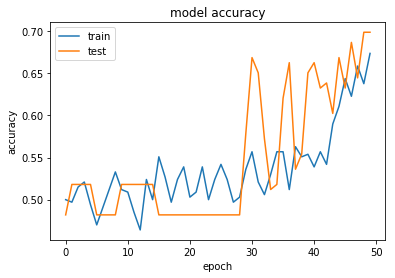

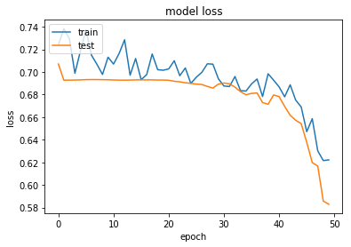

```python
plt.plot(noise_dense_04.history['acc'])
plt.plot(noise_dense_04.history['val_acc'])
plt.title('model accuracy')
plt.ylabel('accuracy')
plt.xlabel('epoch')
plt.legend(['train', 'test'], loc='upper left')
plt.show()

plt.plot(noise_dense_04.history['loss'])
plt.plot(noise_dense_04.history['val_loss'])
plt.title('model loss')
plt.ylabel('loss')
plt.xlabel('epoch')
plt.legend(['train', 'test'], loc='upper left')
plt.show()
```

#### 1.4.2.4 Sub-plot the Results - Loss

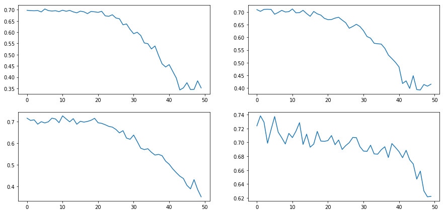

```python
fig = plt.figure(figsize=(15,15))

plt.subplot(4, 2, 1)
plt.plot(noise_dense_01.history['loss'])

plt.subplot(4, 2, 2)
plt.plot(noise_dense_02.history['loss'])

plt.subplot(4, 2, 3)
plt.plot(noise_dense_03.history['loss'])

plt.subplot(4, 2, 4)
plt.plot(noise_dense_04.history['loss'])
```

#### 1.4.2.5 Sub-plot the Results - Accuracy

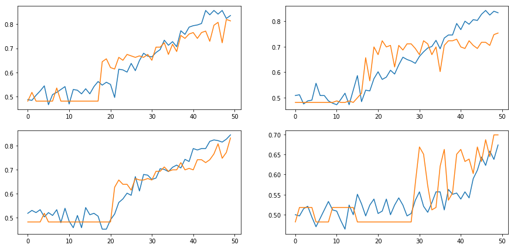

```python
fig = plt.figure(figsize=(15,15))

plt.subplot(4, 2, 1)
plt.plot(noise_dense_01.history['acc'])
plt.plot(noise_dense_01.history['val_acc'])

plt.subplot(4, 2, 2)
plt.plot(noise_dense_02.history['acc'])
plt.plot(noise_dense_02.history['val_acc'])

plt.subplot(4, 2, 3)
plt.plot(noise_dense_03.history['acc'])
plt.plot(noise_dense_03.history['val_acc'])

plt.subplot(4, 2, 4)
plt.plot(noise_dense_04.history['acc'])
plt.plot(noise_dense_04.history['val_acc'])
```

### 1.4.3 Both Convolution and Dense Layers

#### 1.4.3.1 Create the Model

```python
model = Sequential()

model.add(Conv2D(16, (3,3), dilation_rate=2, strides=1, kernel_initializer='normal', use_bias=True, input_shape = X.shape[1:]))
model.add(GaussianNoise(0.1))
model.add(Activation("relu"))
model.add(MaxPooling2D(pool_size=(2,2), padding="same"))
model.add(Dropout(0.3))

model.add(Conv2D(32, (3,3), dilation_rate=2, strides=1, kernel_initializer='normal', use_bias=True))
model.add(Activation("relu"))
model.add(GaussianNoise(0.1))
model.add(MaxPooling2D(pool_size=(2,2), padding="same"))
model.add(Dropout(0.3))

model.add(Conv2D(64, (3,3), dilation_rate=2, strides=1, kernel_initializer='normal', use_bias=True))
model.add(Activation("relu"))
model.add(GaussianNoise(0.1))
model.add(MaxPooling2D(pool_size=(2,2), padding="same"))
model.add(Dropout(0.3))

model.add(Conv2D(128, (3,3), dilation_rate=2, strides=1, kernel_initializer='normal', use_bias=True))
model.add(Activation("relu"))
model.add(GaussianNoise(0.1))
model.add(MaxPooling2D(pool_size=(2,2), padding="same"))
model.add(Dropout(0.3))

model.add(Flatten())
model.add(Dense(32, kernel_initializer='normal', use_bias=True))
model.add(GaussianNoise(0.1))
model.add(Activation("relu"))
model.add(Dropout(0.1))

model.add(Dense(32, kernel_initializer='normal', use_bias=True))
model.add(GaussianNoise(0.1))
model.add(Activation("relu"))
model.add(Dropout(0.1))

model.add(Dense(32, kernel_initializer='normal', use_bias=True))
model.add(Activation("relu"))
model.add(GaussianNoise(0.1))
model.add(Dropout(0.1))

model.add(Dense(1))
model.add(Activation("sigmoid"))

optimizer = Adamax(lr=0.01)

model.compile(loss="binary_crossentropy",
             optimizer=optimizer,
             metrics=['accuracy'])
```

#### 1.4.3.2 Fit the Model

```python
noise_both = model.fit(X, y, batch_size=64, epochs=100, validation_split=0.33)
```

```
Train on 334 samples, validate on 166 samples
```

#### 1.4.3.3 Visualise the Results

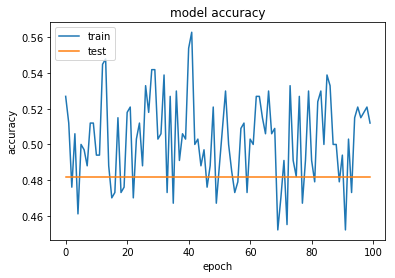

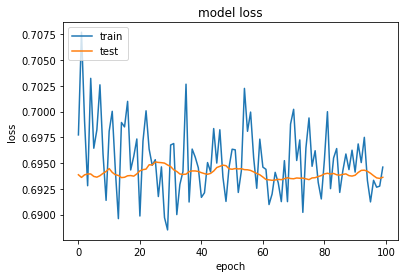

```python
plt.plot(noise_both.history['acc'])
plt.plot(noise_both.history['val_acc'])
plt.title('model accuracy')
plt.ylabel('accuracy')
plt.xlabel('epoch')
plt.legend(['train', 'test'], loc='upper left')
plt.show()

plt.plot(noise_both.history['loss'])
plt.plot(noise_both.history['val_loss'])
plt.title('model loss')
plt.ylabel('loss')
plt.xlabel('epoch')
plt.legend(['train', 'test'], loc='upper left')
plt.show()
```